# Week09a_Lab_CreatingFunctions

Hannah Merges

2023-04-10

## Introduction to Lab Assignment

This lab assignment is to help us practice with functions. The goal is to make one function to use for tidying data that can be applied to many different datasets and to make another function that is helpful when plotting multiple figures with the same style/type of graph.

## Load Libraries

```r
library(tidyverse)
library(here)
library(PNWColors)
library(palmerpenguins)
```

## Read in the Data

We are going to be using conductivity and depth data from a recent study which collected water samples and background biogeochemistry from various sites in Moorea, French Polynesia.

```r
Conductivity <- read_csv(here("Week_09", "Data", "CondData.csv"))
Depth <- read_csv(here("Week_09", "Data", "DepthData.csv"))
TPC <- read_csv(here("Week_09", "Data", "Topt_data.csv"))
SiteChar <- read_csv(here("Week_09", "Data", "site.characteristics.data.csv"))
```

## Make a function that helps with tidying data

For this example, we are going to convert the meters to feet. Though perhaps scientifically less relevant, in case you are an American unable to imagine meters to feet- this function can help you with visualizing the data. And if you are based in a US system and need to switch to meters, this can be a quick flip to convert feet to meters as well!

```r
MtoF <- function() {feet <- (meters)*3.28084
}

MtoF <- function(meters) {feet <- (meters)*3.28084
}

MtoF <- function(meters) {feet <- (meters)*3.28084 # this equation gives you conversion of meters to feet
return(feet)} ## this will return feet as the output based on the calculation of the function meters

## you can use this in our loaded Depth data from Moorea:
DepthData_feet <-Depth %>%
  mutate(Depth_Feet=(MtoF(Depth)))

## you can also use this for any other dataset with data in meters. Let's look at an example that doesn't use depth in water. You could use this for converting running distance from meters to feet to prepare for a race or the height of trees in a forested area. Let's try it with root/shoot data from nitrogen enrichment experiments (and assume in this case for convenience that shoot height is indeed measured in meters)
Shoots <- read_csv(here("Week_09", "Data", "rootshoot.csv"))

ShootHeight <-Shoots %>%
  mutate(Shoot_Feet=(MtoF(RootShoot)))
```

## Make another function that helps with plotting

This plot function can be used to clean the amount of code we need to include in each plot. We will be using the Moorea Coral Reef data on fish counts based on treatment and coral diversity.

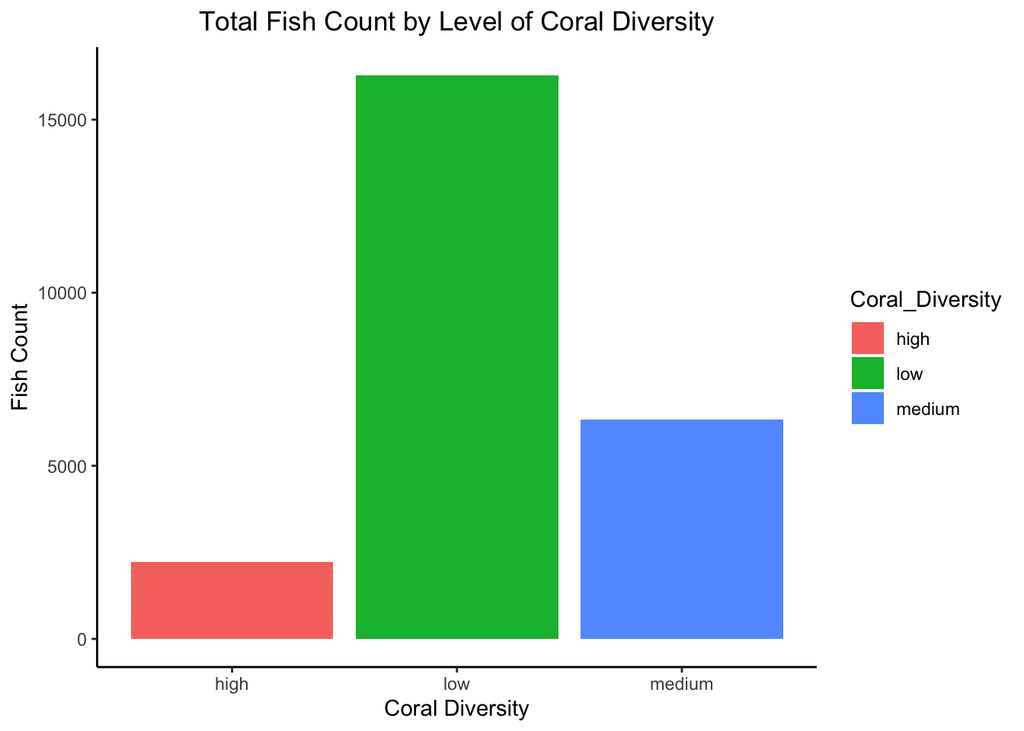

```r
MCR_Fishies <- read_csv(here("Week_09", "Data", "MCR_JCU_PLoS_DataArchive_20150121.csv"))

MCR_FishCount <- MCR_Fishies %>%
  group_by(Location, Coral_Diversity, Treatment) %>%
  summarize(sumtotal=sum(Count))

#make a plot
ggplot(data=MCR_FishCount,
       aes(x=Coral_Diversity,
           y=sumtotal,
           fill=Coral_Diversity)) +
  geom_col() +
  theme_classic() +
  labs(title="Total Fish Count by Level of Coral Diversity",
       x="Coral Diversity",
       y="Fish Count") +
  theme(plot.title=element_text(hjust=0.5))
```

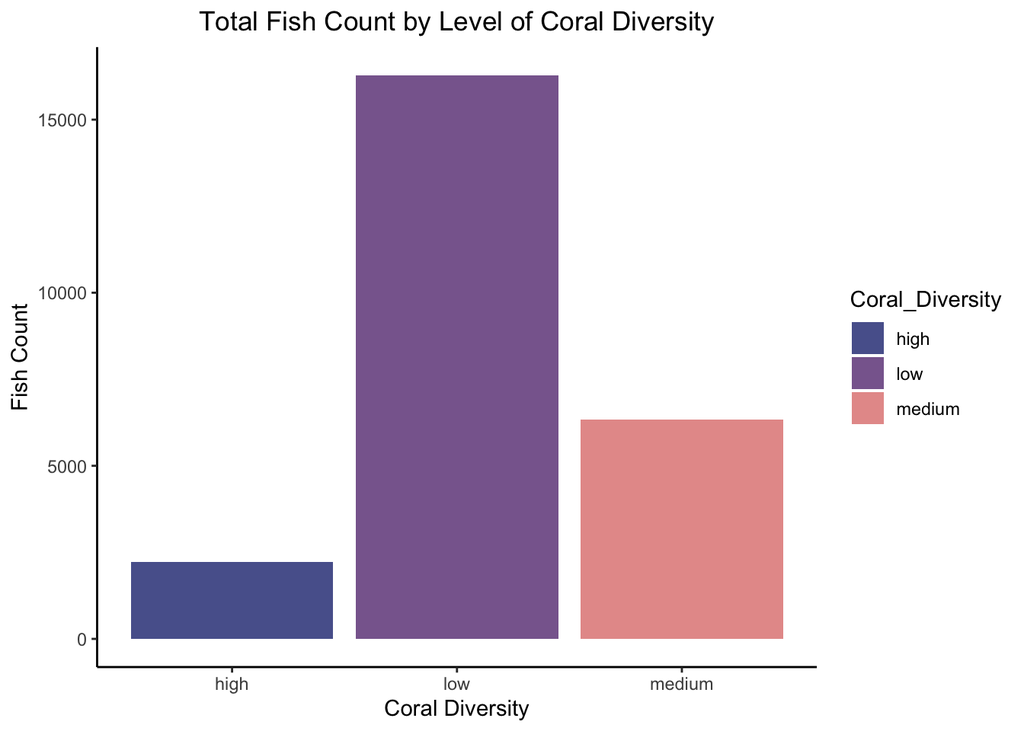

```r
##get rid of all the lines in this bar graph --> redo the tidy data above to group by and summarize columns


testplot <- ggplot(data=MCR_FishCount,
       aes(x=Coral_Diversity,
           y=sumtotal,
           fill=Coral_Diversity)) +
  geom_col() +
  theme_classic() +

  scale_fill_manual(values=pnw_palette("Starfish", n=3, type="discrete")) + ##make sure to include "values" when using pnw palette!!
  labs(title="Total Fish Count by Level of Coral Diversity",
       x="Coral Diversity",
       y="Fish Count") +
  theme(plot.title=element_text(hjust=0.5))
testplot
```

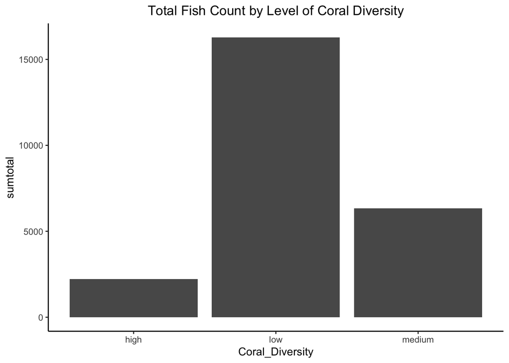

```r
## now based off this plot, create a function that helps us from having to type all of this out again and again for different plots

Plot_Themes_Titles <-function(data = MCR_FishCount, x, y){
  ggplot(data,
         aes(x = {{x}}, y = {{y}})) +
    geom_col() +
    theme_classic() + ## this needs to go first because this is sets the defaults and then anything after this will modify default
    theme(plot.title=element_text(hjust=0.5))
  }
## if this went first, it would get overwritten by the classic theme

Plot_Themes_Titles(x=Coral_Diversity, y=sumtotal) +
  labs(title="Total Fish Count by Level of Coral Diversity")
```

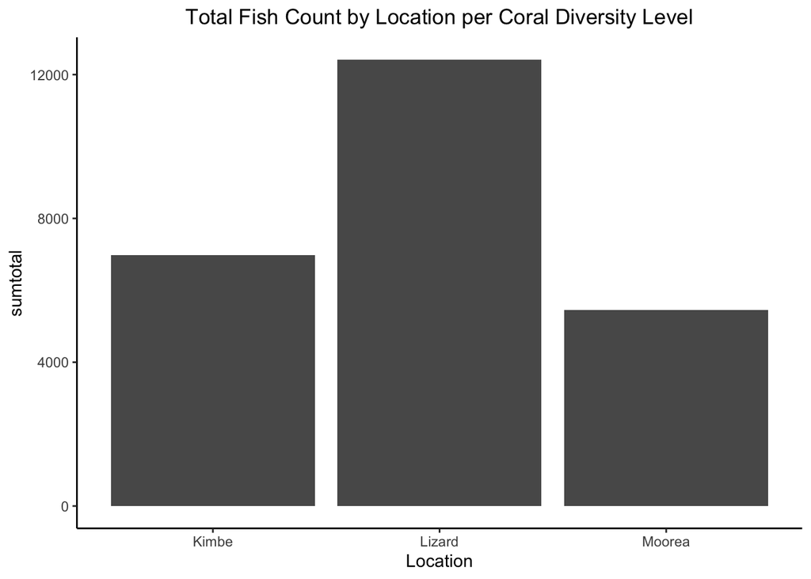

```r
Plot_Themes_Titles(x=Location, y=sumtotal) +
  labs(title="Total Fish Count by Location per Coral Diversity Level")
```

## Summary This plot function is useful for centering your title and using a classic theme that gets rid of the grid lines on the chart. I struggled to figure out how to get the scale_fill working for this plot as well, so I decided to leave the plot function with the two other theme features.  
I was already able to apply this lab to my own research to help me process some data, so I am excited to continue practicing the uses of creating your own function.